# Pràctica 2

Ramon Padilla i Àngel Flores

23/05/2022

## 1- Descripció del dataset. Perquè és important i quina pregunta/problema pretén respondre?

Es tracta d’un dataset que conté els indicadors dels vins. A més, el dataset també conté una variable que indica la qualitat del vi. D’aquesta manera, es podria estudiar quins indicadors estan més relacionats amb una vi de qualitat o, dit d’una altra manera, quines característiques tenen els vins de qualitat.

```r
if (!require('plotly')) install.packages('plotly'); library('plotly')
if(!require(grid)) install.packages('grid', repos='http://cran.us.r-project.org'); library(grid)
if(!require(gridExtra)) install.packages('gridExtra', repos='http://cran.us.r-project.org'); library(gridExtra)
if(!require(tidyverse)) install.packages('tidyverse', repos='http://cran.us.r-project.org'); library(tidyverse)
if(!require(corrplot)) install.packages('corrplot', repos='http://cran.us.r-project.org'); library(corrplot)
if (!require('caTools')) install.packages('caTools');library('caTools')
if (!require('rpart')) install.packages('rpart');library('rpart')
if (!require('rpart.plot')) install.packages('rpart.plot');library('rpart.plot')
if (!require('caret')) install.packages('caret');library('caret')
if (!require('e1071')) install.packages('e1071');library('e1071')


options(scipen = 999)
df<-read.csv("winequality-red.csv", sep=",", na.strings = "NA")
```

Carreguem el Dataset i procedim a analitzar-lo.

```r
head(df)
```

```
##   fixed.acidity volatile.acidity citric.acid residual.sugar chlorides
## 1           7.4             0.70        0.00            1.9     0.076
## 2           7.8             0.88        0.00            2.6     0.098
## 3           7.8             0.76        0.04            2.3     0.092
## 4          11.2             0.28        0.56            1.9     0.075
## 5           7.4             0.70        0.00            1.9     0.076
## 6           7.4             0.66        0.00            1.8     0.075
##   free.sulfur.dioxide total.sulfur.dioxide density   pH sulphates alcohol
## 1                  11                   34  0.9978 3.51      0.56     9.4
## 2                  25                   67  0.9968 3.20      0.68     9.8
## 3                  15                   54  0.9970 3.26      0.65     9.8
## 4                  17                   60  0.9980 3.16      0.58     9.8
## 5                  11                   34  0.9978 3.51      0.56     9.4
## 6                  13                   40  0.9978 3.51      0.56     9.4
##   quality
## 1       5
## 2       5
## 3       5
## 4       6
## 5       5
## 6       5
```

```r
tail(df)
```

```
##      fixed.acidity volatile.acidity citric.acid residual.sugar chlorides
## 1594           6.8            0.620        0.08            1.9     0.068
## 1595           6.2            0.600        0.08            2.0     0.090
## 1596           5.9            0.550        0.10            2.2     0.062
## 1597           6.3            0.510        0.13            2.3     0.076
## 1598           5.9            0.645        0.12            2.0     0.075
## 1599           6.0            0.310        0.47            3.6     0.067
##      free.sulfur.dioxide total.sulfur.dioxide density   pH sulphates alcohol
## 1594                  28                   38 0.99651 3.42      0.82     9.5
## 1595                  32                   44 0.99490 3.45      0.58    10.5
## 1596                  39                   51 0.99512 3.52      0.76    11.2
## 1597                  29                   40 0.99574 3.42      0.75    11.0
## 1598                  32                   44 0.99547 3.57      0.71    10.2
## 1599                  18                   42 0.99549 3.39      0.66    11.0
##      quality
## 1594       6
## 1595       5
## 1596       6
## 1597       6
## 1598       5
## 1599       6
```

```r
str(df)
```

```
## 'data.frame':    1599 obs. of  12 variables:
##  $ fixed.acidity       : num  7.4 7.8 7.8 11.2 7.4 7.4 7.9 7.3 7.8 7.5 ...
##  $ volatile.acidity    : num  0.7 0.88 0.76 0.28 0.7 0.66 0.6 0.65 0.58 0.5 ...
##  $ citric.acid         : num  0 0 0.04 0.56 0 0 0.06 0 0.02 0.36 ...
##  $ residual.sugar      : num  1.9 2.6 2.3 1.9 1.9 1.8 1.6 1.2 2 6.1 ...
##  $ chlorides           : num  0.076 0.098 0.092 0.075 0.076 0.075 0.069 0.065 0.073 0.071 ...
##  $ free.sulfur.dioxide : num  11 25 15 17 11 13 15 15 9 17 ...
##  $ total.sulfur.dioxide: num  34 67 54 60 34 40 59 21 18 102 ...
##  $ density             : num  0.998 0.997 0.997 0.998 0.998 ...
##  $ pH                  : num  3.51 3.2 3.26 3.16 3.51 3.51 3.3 3.39 3.36 3.35 ...
##  $ sulphates           : num  0.56 0.68 0.65 0.58 0.56 0.56 0.46 0.47 0.57 0.8 ...
##  $ alcohol             : num  9.4 9.8 9.8 9.8 9.4 9.4 9.4 10 9.5 10.5 ...
##  $ quality             : int  5 5 5 6 5 5 5 7 7 5 ...
```

```r
nrow(df)
```

```
## [1] 1599
```

```r
summary(df)
```

```
##  fixed.acidity   volatile.acidity  citric.acid    residual.sugar
##  Min.   : 4.60   Min.   :0.1200   Min.   :0.000   Min.   : 0.900
##  1st Qu.: 7.10   1st Qu.:0.3900   1st Qu.:0.090   1st Qu.: 1.900
##  Median : 7.90   Median :0.5200   Median :0.260   Median : 2.200
##  Mean   : 8.32   Mean   :0.5278   Mean   :0.271   Mean   : 2.539
##  3rd Qu.: 9.20   3rd Qu.:0.6400   3rd Qu.:0.420   3rd Qu.: 2.600
##  Max.   :15.90   Max.   :1.5800   Max.   :1.000   Max.   :15.500
##    chlorides       free.sulfur.dioxide total.sulfur.dioxide    density
##  Min.   :0.01200   Min.   : 1.00       Min.   :  6.00       Min.   :0.9901
##  1st Qu.:0.07000   1st Qu.: 7.00       1st Qu.: 22.00       1st Qu.:0.9956
##  Median :0.07900   Median :14.00       Median : 38.00       Median :0.9968
##  Mean   :0.08747   Mean   :15.87       Mean   : 46.47       Mean   :0.9967
##  3rd Qu.:0.09000   3rd Qu.:21.00       3rd Qu.: 62.00       3rd Qu.:0.9978
##  Max.   :0.61100   Max.   :72.00       Max.   :289.00       Max.   :1.0037
##        pH          sulphates         alcohol         quality
##  Min.   :2.740   Min.   :0.3300   Min.   : 8.40   Min.   :3.000
##  1st Qu.:3.210   1st Qu.:0.5500   1st Qu.: 9.50   1st Qu.:5.000
##  Median :3.310   Median :0.6200   Median :10.20   Median :6.000
##  Mean   :3.311   Mean   :0.6581   Mean   :10.42   Mean   :5.636
##  3rd Qu.:3.400   3rd Qu.:0.7300   3rd Qu.:11.10   3rd Qu.:6.000
##  Max.   :4.010   Max.   :2.0000   Max.   :14.90   Max.   :8.000
```

```r
colSums(is.na(df))
```

```
##        fixed.acidity     volatile.acidity          citric.acid
##                    0                    0                    0
##       residual.sugar            chlorides  free.sulfur.dioxide
##                    0                    0                    0
## total.sulfur.dioxide              density                   pH
##                    0                    0                    0
##            sulphates              alcohol              quality
##                    0                    0                    0
```

```r
colSums(df == "")
```

```
##        fixed.acidity     volatile.acidity          citric.acid
##                    0                    0                    0
##       residual.sugar            chlorides  free.sulfur.dioxide
##                    0                    0                    0
## total.sulfur.dioxide              density                   pH
##                    0                    0                    0
##            sulphates              alcohol              quality
##                    0                    0                    0
```

```r
sum(duplicated(df))
```

```
## [1] 240
```

Podem observar que no hi ha valors nuls ni buits però sí que hi ha molts màxims que s’allunyen molt de la mitjana i la mediana. Hi ha valors duplicats però no són pas preocupants, ja que és possible que dos vins tinguin exactament els mateixos nivells de cada variable. A més a més, no tenim els vins identificats de manera que el fet que dos registres contignuin els mateixos valors no ens permet assegurar que es tracti d’un duplicat.

## 2- Integració i selecció de les dades d’interès a analitzar. Pot ser el resultat d’addicionar diferents datasets o una subselecció útil de les dades originals, en base a l’objectiu que es vulgui aconseguir.

Mostrem gràfiques on aparèixen les diferents variables i la seva relació amb un vi de qualitat excel·lent (qualitat >= 7).

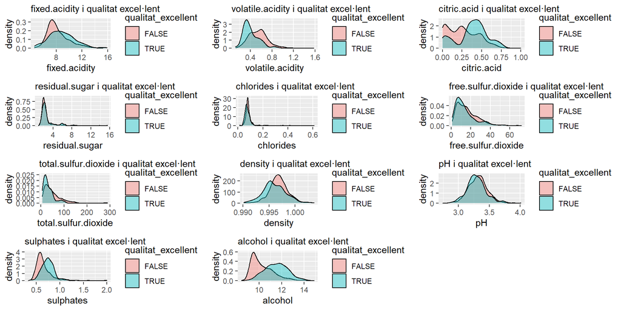

```r
# creació d'una nova variable per identificar el vi com excel·lent o no

df$qualitat_excellent = ifelse(df$quality>= 7, 1, 0)

df_backup = df

df$qualitat_excellent = ifelse(df$qualitat_excellent== 1, "TRUE", "FALSE")

grid.newpage()

fa <- df%>%
  ggplot(aes(x=fixed.acidity, fill=qualitat_excellent)) +
  geom_density(alpha=0.4)+
  labs(x= "fixed.acidity",
       subtitle="fixed.acidity i qualitat excel·lent")

va <- df%>%
  ggplot(aes(x=volatile.acidity, fill=qualitat_excellent)) +
  geom_density(alpha=0.4)+
  labs(x= "volatile.acidity",
       subtitle="volatile.acidity i qualitat excel·lent")

ca <- df%>%
  ggplot(aes(x=citric.acid, fill=qualitat_excellent)) +
  geom_density(alpha=0.4)+
  labs(x= "citric.acid",
       subtitle="citric.acid i qualitat excel·lent")

rs <- df%>%
  ggplot(aes(x=residual.sugar, fill=qualitat_excellent)) +
  geom_density(alpha=0.4)+
  labs(x= "residual.sugar",
       subtitle="residual.sugar i qualitat excel·lent")

c <- df%>%
  ggplot(aes(x=chlorides, fill=qualitat_excellent)) +
  geom_density(alpha=0.4)+
  labs(x= "chlorides",
       subtitle="chlorides i qualitat excel·lent")

fsd <- df%>%
  ggplot(aes(x=free.sulfur.dioxide, fill=qualitat_excellent)) +
  geom_density(alpha=0.4)+
  labs(x= "free.sulfur.dioxide",
       subtitle="free.sulfur.dioxide i qualitat excel·lent")

tsd <- df%>%
  ggplot(aes(x=total.sulfur.dioxide, fill=qualitat_excellent)) +
  geom_density(alpha=0.4)+
  labs(x= "total.sulfur.dioxide",
       subtitle="total.sulfur.dioxide i qualitat excel·lent")

d <- df%>%
  ggplot(aes(x=density, fill=qualitat_excellent)) +
  geom_density(alpha=0.4)+
  labs(x= "density",
       subtitle="density i qualitat excel·lent")

pH <- df%>%
  ggplot(aes(x=pH, fill=qualitat_excellent)) +
  geom_density(alpha=0.4)+
  labs(x= "pH",
       subtitle="pH i qualitat excel·lent")

s <- df%>%
  ggplot(aes(x=sulphates, fill=qualitat_excellent)) +
  geom_density(alpha=0.4)+
  labs(x= "sulphates",
       subtitle="sulphates i qualitat excel·lent")

a <- df%>%
  ggplot(aes(x=alcohol, fill=qualitat_excellent)) +
  geom_density(alpha=0.4)+
  labs(x= "alcohol",
       subtitle="alcohol i qualitat excel·lent")

grid.arrange(fa,va, ca, rs, c, fsd, tsd, d, pH, s, a, ncol=3)
```

```r
df = df_backup
```

Veiem que quan volatile.acidity o totla-sulfure.dioxide tenen valors baixos la qualitat té més probabilitats de ser excel·lent. Tanmateix, també veiem que quan citric.acid, sulphates o alcohol tenen valors alts la qualitat també té més probabilitats de ser excel·lent.

Observem que les variables pH, free.sulfur.dioxide i residual sugar estan molt poc relacionades amb la qualitat i també estan molt poc relacionades amb qualitat excel·lent o no.

Podriem plantejar eliminar aquestes variables, però s’ha considerat que al ser un dataset que tampoc té un nombre excessiu de variables i que la proporció de registres i número de variables és bona, no cal eliminar cap variable.

## 3- Neteja de les dades.

### 3.1. Les dades contenen zeros o elements buits? Gestiona cadascun d’aquests casos.

No, no tenim valors nuls. Tenim valors 0 però podrien ser valors normals.

### 3.2. Identifica i gestiona els valors extrems.

D’altra banda, analitzem els outliers.

```r
paste0("Núm. registres abans de la neteja de outliers: " , nrow(df))
```

```
## [1] "Núm. registres abans de la neteja de outliers: 1599"
```

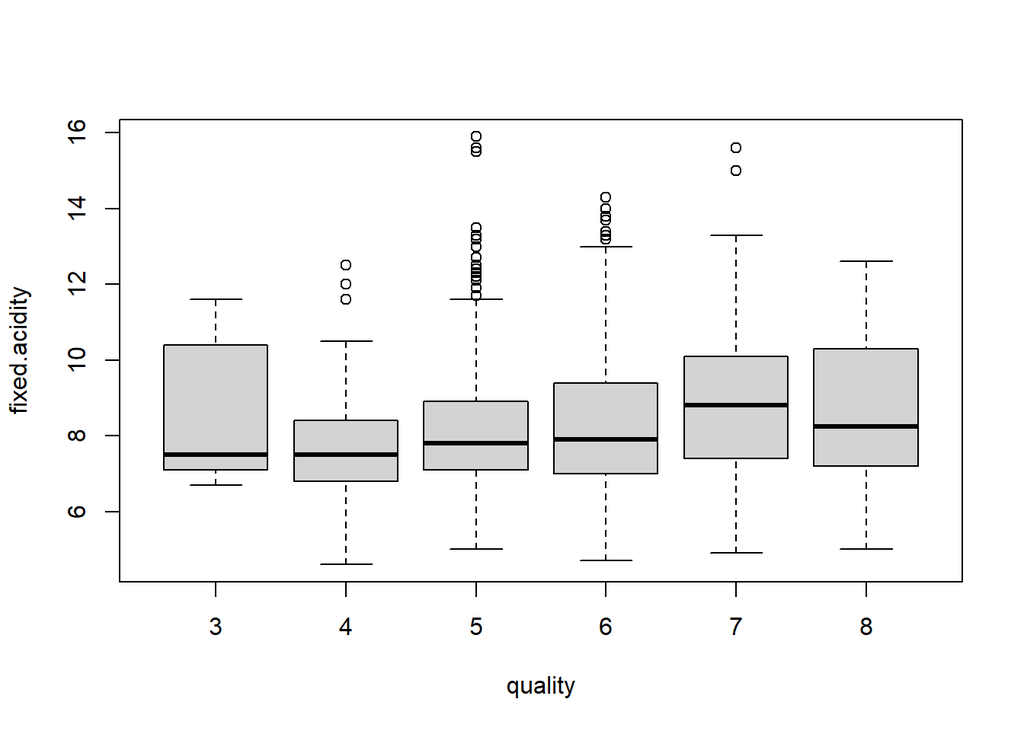

```r
boxplot(df$fixed.acidity ~ df$quality, xlab="quality", ylab="fixed.acidity")
```

```r
quantile(df$fixed.acidity, c(.999))
```

```
## 99.9%
##  15.6
```

```r
df$quality[df$fixed.acidity > 15.6]
```

```
## [1] 5
```

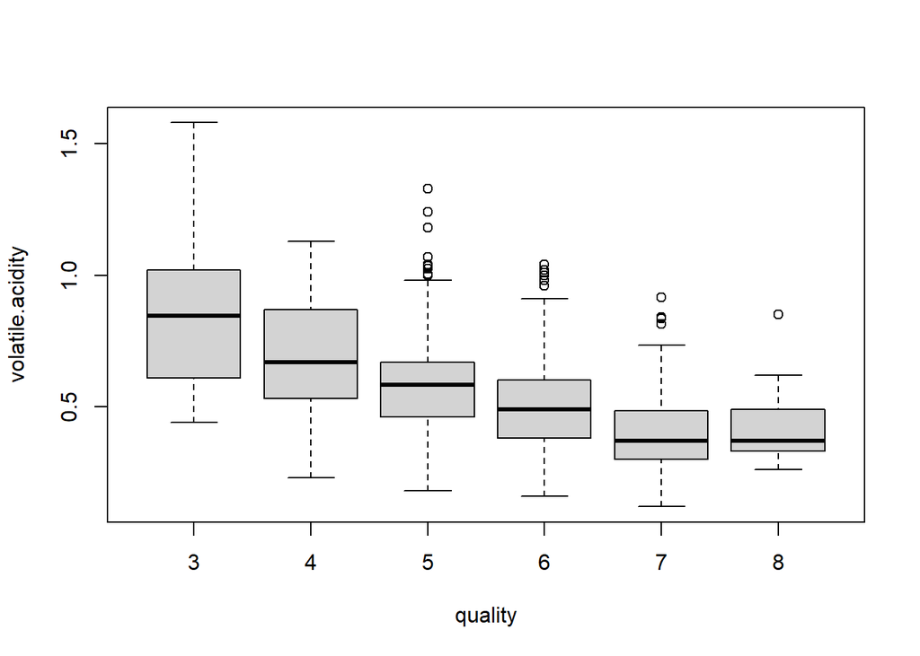

```r
df <- df[-c(which(df$fixed.acidity > 15.6,)), ]
#Comprovem que el 99.9% dels valors es troben per sota de 15.6 i identifiquem 1 valor extrem

boxplot(df$volatile.acidity ~ df$quality, xlab="quality", ylab="volatile.acidity")
```

```r
quantile(df$volatile.acidity, c(.999))
```

```
## 99.9%
##  1.33
```

```r
df$quality[df$volatile.acidity > 1.33]
```

```
## [1] 3
```

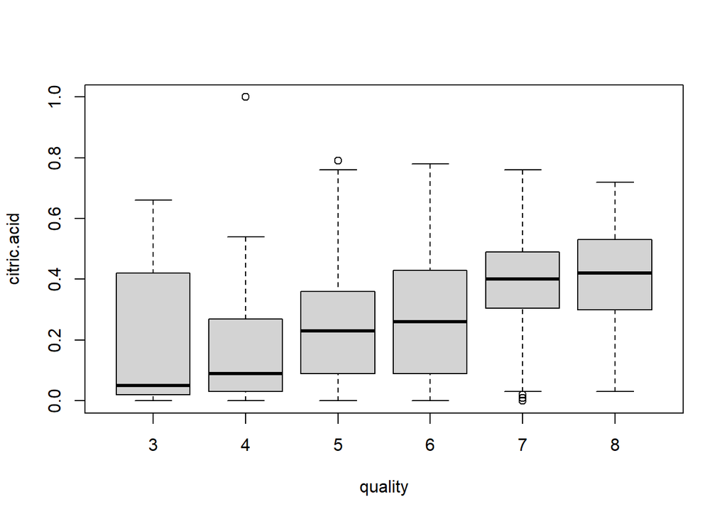

```r
df <- df[-c(which(df$volatile.acidity > 1.33,)), ]
#Comprovem que el 99.9% dels valors es troben per sota de 1.33 i identifiquem 1 valor extrem

boxplot(df$citric.acid ~ df$quality, xlab="quality", ylab="citric.acid")
```

```r
quantile(df$citric.acid, c(.999))
```

```
##   99.9%
## 0.78404
```

```r
df$quality[df$citric.acid > 0.78402]
```

```
## [1] 4 5
```

```r
df <- df[-c(which(df$citric.acid > 0.78402,)), ]
quantile(df$citric.acid, c(.001))
```

```
## 0.1%
##    0
```

```r
df$quality[df$citric.acid < 0]
```

```
## integer(0)
```